# QTM 151 - Introduction to Statistical Computing II

Lecture 04 - Mathematical Operations, Arrays, and Random Numbers

Danilo Freire

danilo.freire@emory.edu

Emory University

11 September, 2024

# Welcome to another lecture! 😊

# Brief recap 📚

## In the last lecture, we learned how to:

- Install packages in Python using `conda install`
- Create, access, and modify variables
- Manipulate lists
- Use the `print()` function to display information
- Create histograms and scatter plots using `matplotlib`
- [Assignment 01](https://github.com/danilofreire/qtm151/blob/main/assignments/02-assignment.ipynb) is due today! 🚨
- Assignment 02 is already online on Canvas and [GitHub](https://github.com/danilofreire/qtm151/blob/main/assignments/02-assignment.ipynb)
- Feel free to email your assignments to me at danilo.freire@emory.edu or submit it via Canvas (hopefully it is working now!)
- We will mark them and provide feedback on your work soon

# Questions?

## Today’s Agenda

### Introducing NumPy and `random`

- [NumPy](https://numpy.org) (short for “Numerical Python”) is a library that provides support for large, multi-dimensional arrays and matrices
- [An array](https://numpy.org/doc/stable/user/absolute_beginners.html) is a collection of numbers that are arranged in a regular grid (vector, matrix, high-dimensional array - tensors)
- In simpler terms, NumPy arrays are a “super-powered list of numbers”
- NumPy is the backbone of many other libraries in Python, such as `pandas` and `scikit-learn`
- We will also learn about the `random` module, which generates random numbers
- NumPy already comes with Anaconda, so you don’t need to install it
- In case you are using a different Python distribution, you can install NumPy using `conda install numpy` or `pip install numpy`
- The alias for NumPy is `np`, so you can import it using `import numpy as np`
- The `random` module is part of the Python Standard Library, so you don’t need to install it
- You can just import it using `import random`
  - Interestingly, the `random` module does not have an alias 🤷🏻‍♂️

[figure not shown]

# Let’s get started! 🚀

## Importing NumPy and Matplotlib

- As usual, we start by importing the libraries we will use
- NumPy has several functions
- For instance, $ln(x), e^x, sin(x), cos(x), \sqrt{x}$
- Remember that exponentiation in Python is done using `**`, not `^`
- You can check a list of NumPy functions [here](https://numpy.org/doc/stable/reference/routines.math.html) (there are many!)

```python
# Importing packages
import numpy as np
import matplotlib.pyplot as plt

# log(x) computes the logarithm with base "e" (Euler constant)
# exp(x) compute the Euler constant raised to the power of "x"
# sin(x) computes the sine of x
# cos(x) computes the cosine of x
# In this example, we're substituting x = 1
print(np.log(1))
print(np.exp(1))
print(np.sin(1))
print(np.cos(1))
print(np.sqrt(1))
```

```
0.0
2.718281828459045
0.8414709848078965
0.5403023058681398
1.0
```

## Try it yourself! 🧠

- Create a new variable, $x = 5$
- Compute $\pi x^2$
- Compute $\frac{1}{\sqrt{2\pi}}e^{-x^2}$
  - This is the probability density function of the standard normal distribution (don’t worry if you don’t know what it is yet! 🤓) Appendix 01
- Don’t forget how to exponentiate in Python 😉

```python
x = 10
x ** 5

# Not x^5
```

```
100000
```

# Vector arrays with NumPy 📊

## Creating arrays from lists

- NumPy arrays are created using the `np.array()` function
- We can create arrays from lists
- We can also create arrays with a sequence of numbers using `np.arange()`
- We can create arrays with zeros or ones using `np.zeros()` and `np.ones()`

## Creating arrays from lists

- Create an array from a list
- $a = \begin{pmatrix} 1 \\ 2 \\ 3 \end{pmatrix}$
- $b = \begin{pmatrix} 0 \\ 1 \\ 0\end{pmatrix}$
- $c = \begin{pmatrix} 10 \\ 100 \\ 1000 \\ 2000 \\ 5000 \end{pmatrix}$
- $d = \begin{pmatrix} 4 \\ 2 \end{pmatrix}$

```python
vec_a  = np.array([1,2,3])
vec_b  = np.array([0,1,0])
vec_c  = np.array([10,100,1000,2000,5000])
vec_d  = np.array([4,2])
```

## Accessing an element of an array

- We can access elements of an array using square brackets `[]`
- Remember that Python is zero-indexed
- Access the first and the third element of $a$

```python
print(vec_a)
print(vec_a[0])
print(vec_a[2])
```

```
[1 2 3]
1
3
```

## Operations with a single array and a scalar

- We can perform operations with a single array and a scalar
- For instance, we can add or multiply a scalar to an array
- Add 2 to each element of $a$
- $a + 2 = \begin{pmatrix} a_1 + 2 \\ a_2 + 2 \\ a_3 + 2 \end{pmatrix}$

```python
# Print the original array
print(vec_a)

# Adding 2 to each element of a
print(vec_a + 2)
```

```
[1 2 3]
[3 4 5]
```

```python
print(vec_a * 2)
print(vec_a / 2)
print(vec_a + 2)
print(vec_a ** 2)
```

```
[2 4 6]
[0.5 1.  1.5]
[3 4 5]
[1 4 9]
```

## Element-by-element addition between two arrays of the same size

$a + b = \begin{pmatrix} a_1 \\ a_2 \\ a_3 \end{pmatrix} +$ $\begin{pmatrix} b_1 \\ b_2 \\ b_3 \end{pmatrix} =$ $\begin{pmatrix} a_1 + b_1 \\ a_2 + b_2 \\ a_3 + b_3 \end{pmatrix}$

```python
print(vec_a)
print(vec_b)

# When you add two arrays of the same size,
# Python adds the individual elements in each position
print(vec_a + vec_b)
```

```
[1 2 3]
[0 1 0]
[1 3 3]
```

## Element-by-element multiplication between two arrays of the same size

$a * b = \begin{pmatrix} a_1 * b_1 \\ a_2 * b_2 \\ a_3 * b_3 \end{pmatrix}$

```python
print(vec_a)
print(vec_b)

# When you multiply two arrays of the same size,
# Python multiplies the individual elements in each position
print(vec_a * vec_b)

# We can do other similar element-by-element operations
# such as subtraction, and division.
print(vec_a - vec_b)
print(vec_a / vec_b)
```

```
[1 2 3]
[0 1 0]
[0 2 0]
[1 1 3]
[inf  2. inf]
```

# Summary statistics 📊

## Summary statistics of an array

- NumPy provides several functions to compute summary statistics of an array
- For instance, we can compute the mean, median, standard deviation, variance, minimum, and maximum
- We can also compute the sum, product, and cumulative sum

```python
print(np.mean(vec_a))
print(np.std(vec_a))
print(np.min(vec_a))
print(np.median(vec_a))
print(np.max(vec_a))
```

```
2.0
0.816496580927726
1
2.0
3
```

- Try it yourself! Compute the mean of

$e = \begin{pmatrix} 10 \\ 8 \\ 15 \\ 0 \\ 24 \end{pmatrix}$

Appendix 02

## Common pitfall

### Make sure that the arrays are of the same size!

```python
print(vec_a)
print(vec_c)

# Print the shape of the arrays
print(vec_a.shape)
print(vec_c.shape)
```

```
[1 2 3]
[  10  100 1000 2000 5000]
(3,)
(5,)
```

```python
# When you add two arrays of different sizes,
# Python will raise an error
print(vec_a + vec_c)
```

[output not shown]

# Questions?

# Random numbers with Python 🎲

## Generating random numbers

- Why randomness?
  - Simulate different scenarios: high risk or low risk
  - Study properties of a complex system and/or estimator
  - In medicine, randomly assign subjects to treatment or control
  - In finance, simulate stock prices
  - In sports, simulate outcomes of games, etc
- This code creates a vector of random variables generated from a normal distribution
- It has the mean “loc” (location) and standard deviation “scale”
- The number of distinct variabels is “size”

```python
# Generate 10 random variables from a normal distribution
# with mean 0 and standard deviation 1
randomvar_a = np.random.normal(loc=0, scale=1, size=10)
print(randomvar_a)
```

```
[-1.3823323   0.69158767  0.80203002  0.29099632 -2.29902304  0.74139819
 -0.17087196  0.2132853  -0.243135   -1.01824831]
```

## Random numbers differ every time!

- Avoid this problem by drawing from a “pregenerated” set.
- This is called a seed, and it is set using `np.random.seed()`
- This allows for [reproducibility](https://en.wikipedia.org/wiki/Reproducibility) of results

```python
np.random.seed(151)

random_var_b = np.random.normal(loc=0, scale=1, size=10)
print(random_var_b)
```

```
[-0.63673759  0.53155853  0.99020835 -0.6241344   1.46778078  0.40501276
  1.29817371 -2.61363271  1.35643373  1.87316055]
```

## Compute a histogram with the results

- We can use the `plt.hist()` function to compute a histogram

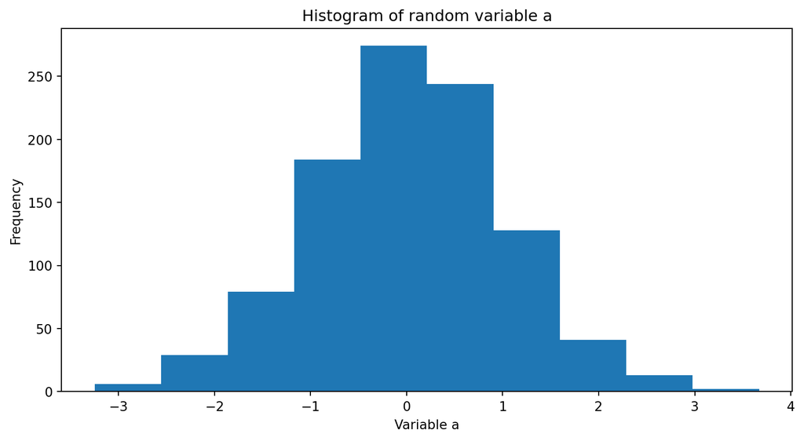

```python
# Create a histogram of the random variable
randomvar_x = np.random.normal(loc=0, scale=1, size=1000)

plt.hist(x = randomvar_x)
plt.xlabel("Variable a")
plt.ylabel("Frequency")
plt.title("Histogram of random variable a")
plt.show()
```

## Try it yourself!

- Try this again with $size = 100, 1000, 10000$ and see how the histogram changes Appendix 03

# And that’s it for today! 🎉

## Summary

- Today we larned to:
  - Use mathematical functions in NumPy
  - Create arrays from lists
  - Access elements of an array
  - Perform operations with a single array and a scalar
  - Perform element-by-element operations between two arrays
  - Compute summary statistics of an array
  - Generate random numbers
  - Create histograms of random variables
- In our next lecture, we will learn how to:
  - Introduce boolean types
  - Test different categories of expressions with text and numbers
  - Study if/else statements

# Questions?

# Thank you and see you next time! 🙏🏼

## Appendix 01

### Mathematical functions in NumPy

- Create a new variable, $x = 5$
- Compute $\pi x^2$
- Compute $\frac{1}{\sqrt{2\pi}}e^{-x^2}$

```python
x = 5
print(np.pi * x ** 2)
print(1 / np.sqrt(2 * np.pi) * np.exp(-x ** 2))
```

```
78.53981633974483
5.540487995575833e-12
```

Back to the main text

## Appendix 02

### Summary statistics of an array

- Compute the mean of
- $e = \begin{pmatrix} 10 \\ 8 \\ 15 \\ 0 \\ 24 \end{pmatrix}$

```python
vec_e = np.array([10, 8, 15, 0, 24])
print(np.mean(vec_e))
```

```
11.4
```

Back to the main text

## Appendix 03

### Histogram of a random variable

- Create a histogram of the random variable
- Try this again with $size = 100, 1000, 10000$ and see how the histogram changes

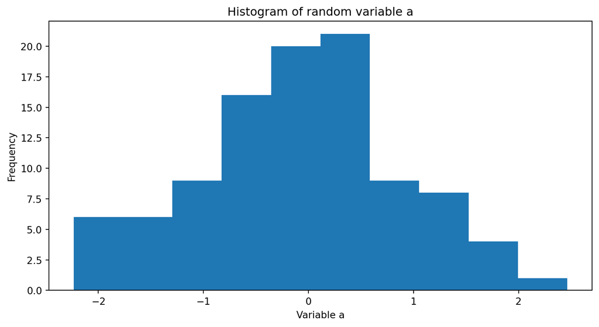

```python
# Create a histogram of the random variable
randomvar_x = np.random.normal(loc=0, scale=1, size=100)

plt.hist(x = randomvar_x)
plt.xlabel("Variable a")
plt.ylabel("Frequency")
plt.title("Histogram of random variable a")
plt.show()
```

Back to the main text

[Maths with NumPy](https://raw.githack.com/danilofreire/qtm151/main/lectures/lecture-04/04-maths-arrays-random.html)